# 과제#4 회귀분석

성원호

5/16/2021

## 데이터 수집 및 할당

```r
library(dplyr)
library(stringr)
# install.packages("QuantPsyc")
library(QuantPsyc)
# install.packages("car")
library(car)
```

```r
library(sjPlot)
library(lmtest)
library(psych)
library(interactions)
library(jtools)
# 국가별 문화 점수(Hofstede model)는 국가별 혁신 정도의 점수와 연관성을 갖는지를 검증한다.

# 국가가 소속한 대륙 또한 독립 변수로서 국가별 혁신 정도 점수와 연관성을 갖는지 검증할 것이다.

# 종속변수 : 국가별 혁신 정도의 점수
index <- read.csv("INSEADGlobalinnovationIndex2018.csv", fileEncoding = "CP949", encoding = "UTF-8")
head(index)
```

```
##   Rank                  Economy Income.Group.Strength.Weakness.
## 1    1              Switzerland                        Strength
## 2    2              Netherlands                        Strength
## 3    3                   Sweden                        Strength
## 4    4           United Kingdom
## 5    5                Singapore
## 6    6 United States of America
##   Strength...Weakness Value Score
## 1            Strength     -  68.4
## 2            Strength     -  63.3
## 3            Strength     -  63.1
## 4            Strength     -  60.1
## 5                         -  59.8
## 6                         -  59.8
```

```r
# 독립변수 : 소속 대륙 및 국가별 문화적 차원 점수(Hofstede model)
hofs <- read.csv("hofstede.csv", fileEncoding = "CP949", encoding = "UTF-8")
head(hofs)
```

```
##     id     title      slug pdi idv mas uai lto ind ivr     Continent
## 1  545  Albania*   albania  90  20  80  70  61  15  15        Europe
## 2 7062  Algeria*   algeria  80  35  35  70  26  32  32        Africa
## 3  546   Angola*    angola  83  18  20  60  15  83  83        Africa
## 4  460 Argentina argentina  49  46  56  86  20  62  62 South America
## 5 7067  Armenia*   armenia  85  22  50  88  61  25  25          Asia
## 6  459 Australia australia  38  90  61  51  21  71  71     Australia
```

## 데이터 정제

```r
# 국가 혁신 지표와 호프 스테드 데이터를 병합하고자 나라 이름들의 컬럼 이름을 Country로 변환해줌
index <- rename(index, "Country" = "Economy")

# 소문자와 대문자의 구별 후 병합해야하므로 소문자로 변환 시켜줌
index$Country <- tolower(index$Country)
head(index)
```

```
##   Rank                  Country Income.Group.Strength.Weakness.
## 1    1              switzerland                        Strength
## 2    2              netherlands                        Strength
## 3    3                   sweden                        Strength
## 4    4           united kingdom
## 5    5                singapore
## 6    6 united states of america
##   Strength...Weakness Value Score
## 1            Strength     -  68.4
## 2            Strength     -  63.3
## 3            Strength     -  63.1
## 4            Strength     -  60.1
## 5                         -  59.8
## 6                         -  59.8
```

```r
hofs <- rename(hofs, "Country" = "slug")
head(hofs)
```

```
##     id     title   Country pdi idv mas uai lto ind ivr     Continent
## 1  545  Albania*   albania  90  20  80  70  61  15  15        Europe
## 2 7062  Algeria*   algeria  80  35  35  70  26  32  32        Africa
## 3  546   Angola*    angola  83  18  20  60  15  83  83        Africa
## 4  460 Argentina argentina  49  46  56  86  20  62  62 South America
## 5 7067  Armenia*   armenia  85  22  50  88  61  25  25          Asia
## 6  459 Australia australia  38  90  61  51  21  71  71     Australia
```

```r
# Country를 기준으로 내부 조인 실행
innovation <- inner_join(index, hofs, by = "Country")
head(innovation)
```

```
##   Rank                  Country Income.Group.Strength.Weakness.
## 1    1              switzerland                        Strength
## 2    2              netherlands                        Strength
## 3    3                   sweden                        Strength
## 4    4           united kingdom
## 5    5                singapore
## 6    6 united states of america
##   Strength...Weakness Value Score  id          title pdi idv mas uai lto ind
## 1            Strength     -  68.4 511    Switzerland  34  68  70  58  74  66
## 2            Strength     -  63.3 487    Netherlands  38  80  14  53  67  68
## 3            Strength     -  63.1 510         Sweden  31  71   5  29  53  78
## 4            Strength     -  60.1 514 United Kingdom  35  89  66  35  51  69
## 5                         -  59.8 506      Singapore  74  20  48   8  72  46
## 6                         -  59.8 515  United States  40  91  62  46  26  68
##   ivr     Continent
## 1  66        Europe
## 2  68        Europe
## 3  78        Europe
## 4  69        Europe
## 5  46          Asia
## 6  68 North America
```

```r
# ivr = ind(같은 값을 가지는 컬럼)이기 때문에 하나를 소거하여 출력
# 국가별 혁신 점수로 산출된 순위를 기준으로 출력하도록 만든다.
innovation <- innovation %>%
  dplyr::select(Rank, Score, id, title, pdi, idv, mas, uai, lto, ind, Continent) %>%
  arrange(Rank)
head(innovation)
```

```
##   Rank Score  id          title pdi idv mas uai lto ind     Continent
## 1    1  68.4 511    Switzerland  34  68  70  58  74  66        Europe
## 2    2  63.3 487    Netherlands  38  80  14  53  67  68        Europe
## 3    3  63.1 510         Sweden  31  71   5  29  53  78        Europe
## 4    4  60.1 514 United Kingdom  35  89  66  35  51  69        Europe
## 5    5  59.8 506      Singapore  74  20  48   8  72  46          Asia
## 6    6  59.8 515  United States  40  91  62  46  26  68 North America
```

- 국가 혁신 인덱스 데이터와 호프스테드 문화모델은 국가 표기에 있어 차이가 존재했음. ex) South Korea <-> korea, repulic of 때문에 데이터를 병합했을 때 Rank가 나오지 않는 나라들은 표기를 직접 csv 데이터 안에서 바꾸어주었으며, 아예 없는 나라들도 존재했음(측정 불가, 데이터 결측 등의 이유라 생각했습니다.)
- pdi : 사회적으로 권력을 갖지 못한 계층이 권력에 순응하는 정도
- idv : 사회구조의 형태를 선호하는 정도(idv가 높으면 사람들은 느슨하게 엮인 사회구조를 선호함)
- mas : 사회가 성취, 영웅, 자기주장에 얼마나 우호적인지, 성공에 어떠한 보상이 있는지를 나타낸 정도
- uai : 사회 구성원들이 불확실하거나 불명확한 상황에 얼마나 불편함을 느끼는지를 나타내는 정도
- lto : 사회의 보수/진보적 정도를 판가름하는 지표(lto가 낮은 사회의 경우 의심을 갖고 사회를 바라보고 과거의 전통 및 규범을 지키고자 노력함)
- ind=ivr : 사회의 관대한 정도, 인간의 자연스러운 욕구를 얼마나 허용하는지를 의미하는 정도

## 다중회귀분석

```r
# lm 함수를 사용하여 종속변수(국가 혁신 점수)와 독립변수(호프 스테드 문화 모형 점수)를 입력하여 할당
regression_1 <- lm(innovation$Score ~ innovation$pdi+innovation$idv+innovation$mas+innovation$uai+innovation$lto+innovation$ind)

#summary 함수를 이용해 회귀분석의 결과를 확인
summary(regression_1)
```

```
##
## Call:
## lm(formula = innovation$Score ~ innovation$pdi + innovation$idv +
##     innovation$mas + innovation$uai + innovation$lto + innovation$ind)
##
## Residuals:
##      Min       1Q   Median       3Q      Max
## -17.6479  -4.8513   0.0172   4.1138  20.0758
##
## Coefficients:
##                 Estimate Std. Error t value Pr(>|t|)
## (Intercept)    37.756810   5.280287   7.151 2.11e-10 ***
## innovation$pdi -0.183478   0.051508  -3.562 0.000588 ***
## innovation$idv  0.172413   0.052190   3.304 0.001366 **
## innovation$mas -0.009424   0.041398  -0.228 0.820439
## innovation$uai -0.029157   0.035347  -0.825 0.411600
## innovation$lto  0.175056   0.029355   5.963 4.65e-08 ***
## innovation$ind  0.051152   0.031655   1.616 0.109569
## ---
## Signif. codes:  0 '***' 0.001 '**' 0.01 '*' 0.05 '.' 0.1 ' ' 1
##
## Residual standard error: 7.178 on 91 degrees of freedom
##   (2 observations deleted due to missingness)
## Multiple R-squared:  0.6604, Adjusted R-squared:  0.638
## F-statistic:  29.5 on 6 and 91 DF,  p-value: < 2.2e-16
```

```r
# jtools의 summ이라는 함수인데 summary와 동일한 기능을 하지만 더 깔끔하게 결과값을 보여준다.
# 정석을 위해 아래 코드부터는 summary 함수를 사용할 것임
summ(regression_1)
```

```
## MODEL INFO:
## Observations: 98 (2 missing obs. deleted)
## Dependent Variable: innovation$Score
## Type: OLS linear regression
##
## MODEL FIT:
## F(6,91) = 29.50, p = 0.00
## R² = 0.66
## Adj. R² = 0.64
##
## Standard errors: OLS
## ---------------------------------------------------
##                         Est.   S.E.   t val.      p
## -------------------- ------- ------ -------- ------
## (Intercept)            37.76   5.28     7.15   0.00
## innovation$pdi         -0.18   0.05    -3.56   0.00
## innovation$idv          0.17   0.05     3.30   0.00
## innovation$mas         -0.01   0.04    -0.23   0.82
## innovation$uai         -0.03   0.04    -0.82   0.41
## innovation$lto          0.18   0.03     5.96   0.00
## innovation$ind          0.05   0.03     1.62   0.11
## ---------------------------------------------------
```

## 표준화 계수값 구하기

```r
lm.beta(regression_1)
```

```
## innovation$pdi innovation$idv innovation$mas innovation$uai innovation$lto
##    -0.32779620     0.31905782    -0.01433764    -0.05344620     0.38844257
## innovation$ind
##     0.10837316
```

```r
round(lm.beta(regression_1), 3)
```

```
## innovation$pdi innovation$idv innovation$mas innovation$uai innovation$lto
##         -0.328          0.319         -0.014         -0.053          0.388
## innovation$ind
##          0.108
```

- lm.beta : 표준화 회귀계수(베타) 값을 출력하는 함수
- round : 가시성을 위해 소수점 세자리까지 올림
- lto의 표준화 계수는 0.388로 가장 높게 나타났기 때문에 혁신 점수에 가장 큰 영향을 미치는 독립변수임을 알 수 있다.

## 다중공선성 진단을 위한 VIF 값 구하기

```r
vif(regression_1)
```

```
## innovation$pdi innovation$idv innovation$mas innovation$uai innovation$lto
##       2.269302       2.499602       1.063091       1.125024       1.137019
## innovation$ind
##       1.205299
```

```r
vif(regression_1) < 10
```

```
## innovation$pdi innovation$idv innovation$mas innovation$uai innovation$lto
##           TRUE           TRUE           TRUE           TRUE           TRUE
## innovation$ind
##           TRUE
```

- vif : 다중공선성으로 인해 회귀모형이 문제가 있다는 것을 의미한다.(분산팽창요인)
- vif 수식 내에서 값이 10 이상 산출되면 다중공선성이 존재하는데, 현재 모든 독립변수들의 vif 값이 10 미만으로 나타나기에 다중공선성에 문제가 되지 않는다는 것을 알 수 있다.

## sjPlot을 이용해 결과표, 도표 출력

```r
tab_model(regression_1, show.se = T, show.ci = F, show.stat = T)
```

[output not shown]

```r
tab_model(regression_1, show.se = T, show.ci = F, show.stat = T,
          pred.labels = c("(Intercept)", "pdi", "idv", "mas", "uai", "lto", "ind"),
          dv.labels = c("innovation score"), file = "regression_1.html")
```

|  | innovation score |  |  |  |
| --- | --- | --- | --- | --- |
| Predictors | Estimates | std. Error | Statistic | p |
| (Intercept) | 37.76 | 5.28 | 7.15 | **<0.001** |
| pdi | -0.18 | 0.05 | -3.56 | **0.001** |
| idv | 0.17 | 0.05 | 3.30 | **0.001** |
| mas | -0.01 | 0.04 | -0.23 | 0.820 |
| uai | -0.03 | 0.04 | -0.82 | 0.412 |
| lto | 0.18 | 0.03 | 5.96 | **<0.001** |
| ind | 0.05 | 0.03 | 1.62 | 0.110 |
| Observations | 98 |  |  |  |
| R<sup>2</sup> / R<sup>2</sup> adjusted | 0.660 / 0.638 |  |  |  |

```r
file.show("regression_1.html")
```

- tab_model : 다중회귀분석의 결과를 표의 형태로 출력해주는 함수
- Predictors를 제외하고 왼쪽부터 회귀 계수, 표준오차, t값, 유의확률로 해석하면 된다.
- Observations(분석에 사용한 사례수), R^2 값과 수정된 R^2 값도 찾아볼 수 있다.

## sjPlot을 이용해 다중회귀분석 도표 작성

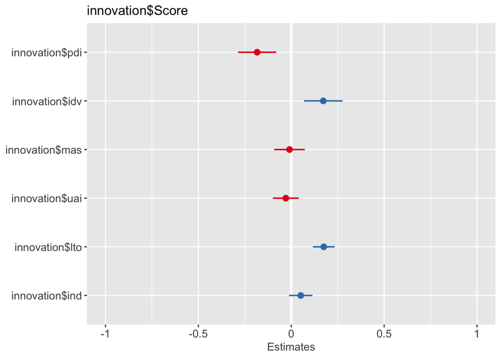

```r
set_theme(axis.title.size = 1.0, axis.textsize = 1.0)
plot_model(regression_1, type = "est", wrap.labels = 5)
```

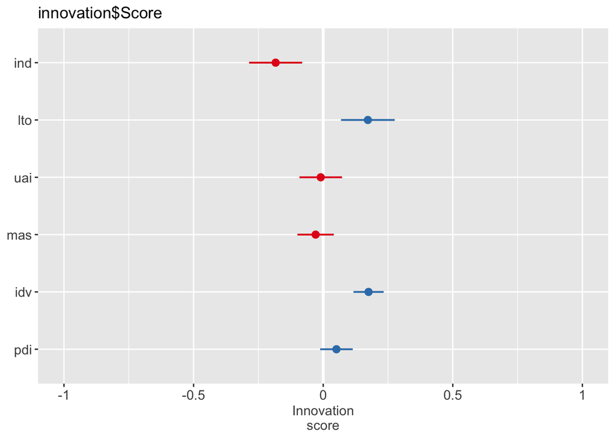

```r
plot_model(regression_1, type = "est", axis.labels = c("pdi", "idv", "mas", "uai","lto", "ind"), axis.title = "Innovation score", wrap.labels = 5)
```

- plot_model 함수를 이용해 저장된 다중회귀분석 결과를 지정하고, y축에는 변수 설명을 label에서 가져오는 대신 lm 함수에 입력했던 독립변수들을 다시 입력해준다.
- lm 함수에 입력했던 것들 : pdi, idv, mas, uai, lto, ind
- 출력되는 그림은 회귀 계수를 나타낸 것이며 선의 길이는 신뢰구간을 의미한다.

## 다중회귀분석 도표에 표준화 계수

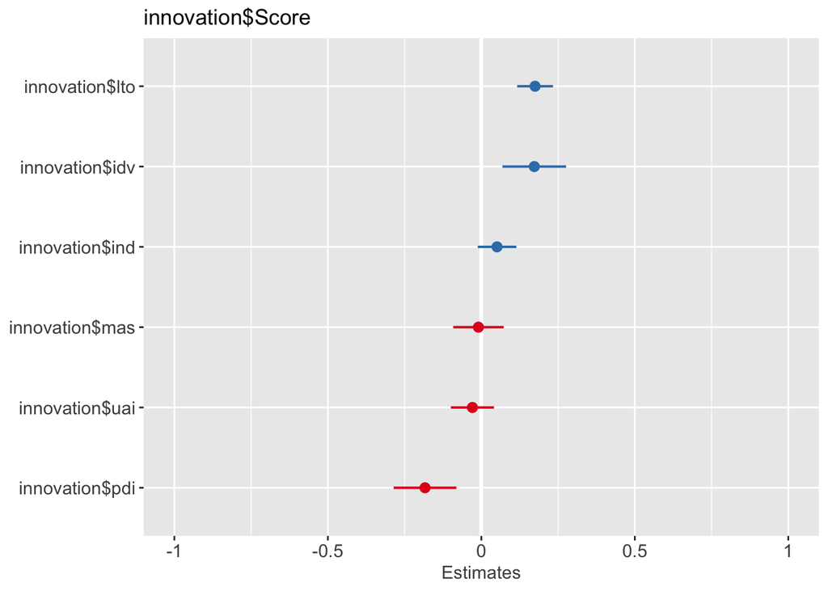

```r
plot_model(regression_1, type = "std", sort.est = T, wrap.labels = 5)
```

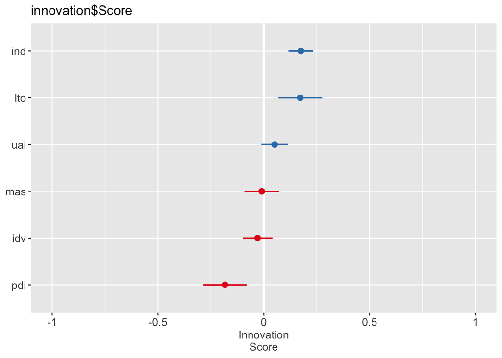

```r
plot_model(regression_1, type = "std", sort.est = T,
           axis.labels = c("pdi", "idv", "mas", "uai", "lto", "ind"), axis.title ="Innovation Score", wrap.labels = 5)
```

- 만약 회귀 계수가 아닌 표준화 계수로 나타내고자 한다면 type의 옵션을 est가 아닌 std로 설정하면 표준화 계수 도표를 출력한다.

## sjPlot을 이용해 다중공선성 진단 및 회귀분석 가정 검정

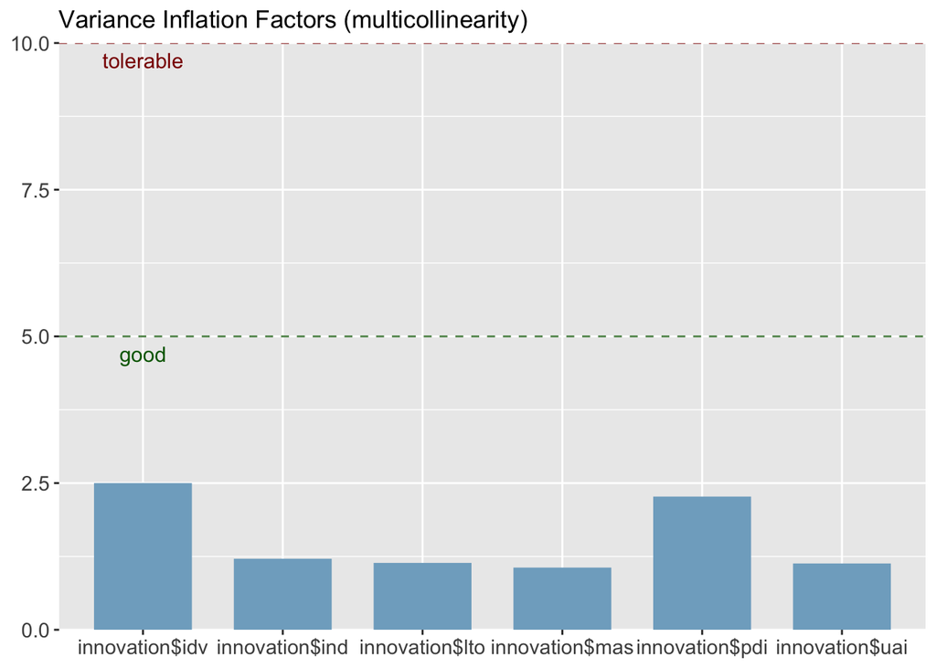

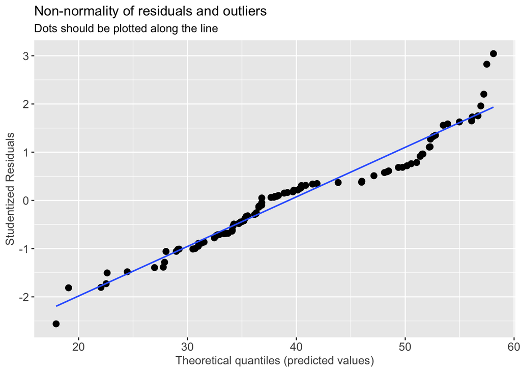

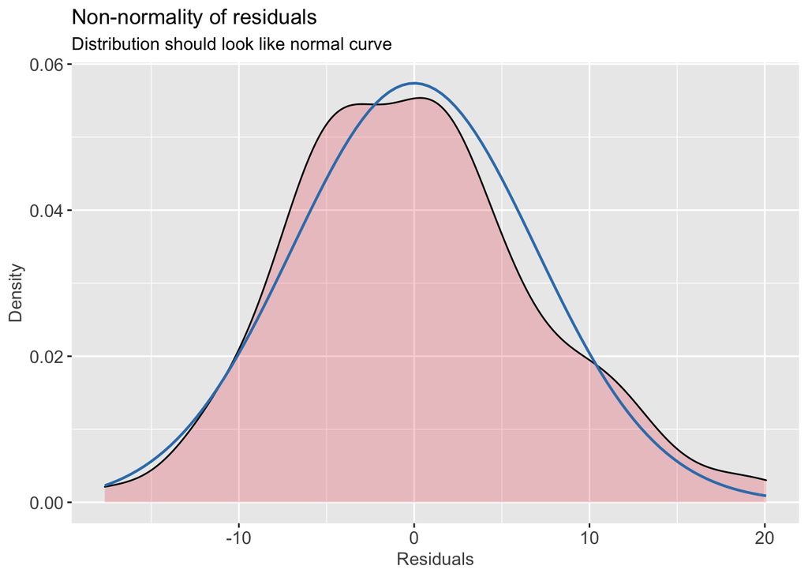

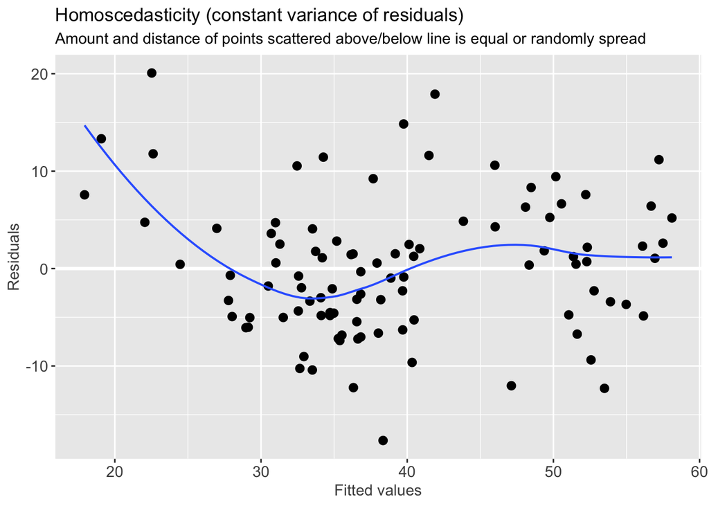

```r
plot_model(regression_1, type = "diag")
```

```r
dwtest(regression_1)
```

```
##
##  Durbin-Watson test
##
## data:  regression_1
## DW = 1.1765, p-value = 5.36e-06
## alternative hypothesis: true autocorrelation is greater than 0
```

- 다중회귀모형에 있어 다중공선성을 진단하고 회귀분석 기본 가정 만족여부를 도표로 출력하려면 위와 같이 입력해주면 된다.(type 옵션이 diag)
- dwtest는 모형의 잔차를 검정하는 함수이다. 기본으로는 단측검정을 수행하고 잔차들의 자기 상관이 0보다 큰지를 검정한다.
- 다중공선성 진단 결과 독립 변수들의 vif 값이 모두 10 이하를 나타내고 있기 때문에 다중공선성으로 인한 문제가 없다는 것을 알 수 있다.

## 다중회귀분석의 전진 선택 모형

```r
# 결측값 제거하기
innovation.none <- na.omit(innovation[c("Score", "pdi","idv","mas","uai","lto", "ind")])

# 전체 모형과 기본 모형 생성
regression_none <- lm(Score ~ pdi+idv+mas+uai+lto+ind, data = innovation.none)
null <- lm(Score ~ 1, data = innovation.none)

# 전진 선택 모형
front <- step(null, scope=list(lower=null, upper = regression_none), direction = "forward")
```

```
## Start:  AIC=486.9
## Score ~ 1
##
##        Df Sum of Sq     RSS    AIC
## + idv   1    6739.6  7067.6 423.27
## + pdi   1    5379.3  8427.8 440.52
## + lto   1    3092.8 10714.4 464.05
## + ind   1    1898.9 11908.3 474.40
## + uai   1     398.5 13408.6 486.03
## <none>              13807.1 486.90
## + mas   1       2.9 13804.2 488.88
##
## Step:  AIC=423.27
## Score ~ idv
##
##        Df Sum of Sq    RSS    AIC
## + lto   1   1411.19 5656.4 403.45
## + pdi   1    436.19 6631.4 419.03
## <none>              7067.6 423.27
## + ind   1    133.52 6934.0 423.40
## + mas   1     32.26 7035.3 424.83
## + uai   1      0.73 7066.8 425.26
##
## Step:  AIC=403.45
## Score ~ idv + lto
##
##        Df Sum of Sq    RSS    AIC
## + pdi   1    797.67 4858.7 390.55
## + ind   1    177.83 5478.5 402.32
## <none>              5656.4 403.45
## + uai   1     83.16 5573.2 403.99
## + mas   1     44.65 5611.7 404.67
##
## Step:  AIC=390.55
## Score ~ idv + lto + pdi
##
##        Df Sum of Sq    RSS    AIC
## + ind   1   133.092 4725.6 389.83
## <none>              4858.7 390.55
## + uai   1    34.797 4823.9 391.84
## + mas   1     0.436 4858.3 392.54
##
## Step:  AIC=389.83
## Score ~ idv + lto + pdi + ind
##
##        Df Sum of Sq    RSS    AIC
## <none>              4725.6 389.83
## + uai   1    34.366 4691.2 391.11
## + mas   1     1.979 4723.6 391.79
```

```r
summary(front)
```

```
##
## Call:
## lm(formula = Score ~ idv + lto + pdi + ind, data = innovation.none)
##
## Residuals:
##      Min       1Q   Median       3Q      Max
## -17.1595  -4.6281   0.1895   3.6371  19.8712
##
## Coefficients:
##             Estimate Std. Error t value Pr(>|t|)
## (Intercept) 35.93988    4.78336   7.514 3.47e-11 ***
## idv          0.17486    0.05062   3.455 0.000832 ***
## lto          0.17047    0.02861   5.959 4.51e-08 ***
## pdi         -0.19078    0.04956  -3.849 0.000217 ***
## ind          0.05077    0.03137   1.618 0.108961
## ---
## Signif. codes:  0 '***' 0.001 '**' 0.01 '*' 0.05 '.' 0.1 ' ' 1
##
## Residual standard error: 7.128 on 93 degrees of freedom
## Multiple R-squared:  0.6577, Adjusted R-squared:  0.643
## F-statistic: 44.68 on 4 and 93 DF,  p-value: < 2.2e-16
```

- 전진선택 분석에서는 결측값을 모두 제거해준 뒤, 독립변수가 하나도 없는 모형을 기본 모형으로 한다.(null이라는 변수에 저장) 이후 단계적으로 모델을 선택하여 분석하는 step 함수를 이용한다. scope 인자에서는 전진 분석의 기본 모형과 필자가 지정한 회귀 모형 변수를 입력해준다.
- AIC : 주어진 데이터에 통계 모델의 상대적 품질을 평가하는 기준으로 낮을 수록 좋다.
- 기본 모형을 통해 출력되는 것들은 Df(자유도), Sum of Sq(제곱합), RSS(잔차 제곱 합), 그리고 AIC가 출력되는 것을 알 수 있다.
- 각 단계를 살펴보면 첫 모형 Score~1은 AIC가 486.9이다. 여기에 idv를 추가시 423.27로 감소한다. 여기에 lto를 추가시 403.45, pdi 추가시 390.55, ind 추가시 389.83까지 감소한다. 그러나 uai를 추가시엔 391.11로 상승하기 때문에 추가하지 않고 Score ~ idv + lto + pdi + ind에서 전진선택을 멈춘다.
- 최종 모형을 살펴보면 F 값은 44.68이고 유의도는 2.2e-16으로 유의수준인 0.05보다 낮게 나타나므로 최종 모형은 의미가 있음을 알 수 있다. 또한 R^2 값은 0.6577로 종속 변수인 혁신 점수의 전체 분산 중 4개의 독립변수가 65.77%를 설명한다는 것을 알 수 있다.

## 다중회귀분석의 후진 선택 모형

```r
# 후진 선택 모형
# 전진 선택 모형과는 달리 direction 인자를 backward로 할당해준다.
rear <- step(regression_none, direction="backward")
```

```
## Start:  AIC=393.06
## Score ~ pdi + idv + mas + uai + lto + ind
##
##        Df Sum of Sq    RSS    AIC
## - mas   1      2.67 4691.2 391.11
## - uai   1     35.06 4723.6 391.79
## <none>              4688.6 393.06
## - ind   1    134.54 4823.1 393.83
## - idv   1    562.30 5250.9 402.16
## - pdi   1    653.76 5342.3 403.85
## - lto   1   1832.27 6520.8 423.38
##
## Step:  AIC=391.11
## Score ~ pdi + idv + uai + lto + ind
##
##        Df Sum of Sq    RSS    AIC
## - uai   1     34.37 4725.6 389.83
## <none>              4691.2 391.11
## - ind   1    132.66 4823.9 391.84
## - idv   1    567.53 5258.8 400.30
## - pdi   1    706.69 5397.9 402.86
## - lto   1   1832.78 6524.0 421.43
##
## Step:  AIC=389.83
## Score ~ pdi + idv + lto + ind
##
##        Df Sum of Sq    RSS    AIC
## <none>              4725.6 389.83
## - ind   1    133.09 4858.7 390.55
## - idv   1    606.38 5332.0 399.66
## - pdi   1    752.93 5478.5 402.32
## - lto   1   1804.20 6529.8 419.52
```

```r
summary(rear)
```

```
##
## Call:
## lm(formula = Score ~ pdi + idv + lto + ind, data = innovation.none)
##
## Residuals:
##      Min       1Q   Median       3Q      Max
## -17.1595  -4.6281   0.1895   3.6371  19.8712
##
## Coefficients:
##             Estimate Std. Error t value Pr(>|t|)
## (Intercept) 35.93988    4.78336   7.514 3.47e-11 ***
## pdi         -0.19078    0.04956  -3.849 0.000217 ***
## idv          0.17486    0.05062   3.455 0.000832 ***
## lto          0.17047    0.02861   5.959 4.51e-08 ***
## ind          0.05077    0.03137   1.618 0.108961
## ---
## Signif. codes:  0 '***' 0.001 '**' 0.01 '*' 0.05 '.' 0.1 ' ' 1
##
## Residual standard error: 7.128 on 93 degrees of freedom
## Multiple R-squared:  0.6577, Adjusted R-squared:  0.643
## F-statistic: 44.68 on 4 and 93 DF,  p-value: < 2.2e-16
```

- 후진 선택 모델은 전진 선택과 달리 유의 하지 않은 변수가 많더라도 p값을 기준으로 변수를 하나씩 제거하여 모든 변수가 유의, 혹은 더 이상 변수가 없을 때까지 제거한다.
- 변수를 하나씩 제거하는 이유 : 다중공선성(a1 변수 삭제 시, a2의 p값에 변동이 생김) 때문이다.
- 첫 단계에서는 필자가 입력한 모든 독립변수를 가정한 회귀 모형이 출력된다.
- AIC가 가장 작아질 때까지 진행한 결과 pdi, idv, lto, ind의 독립변수가 선택된 389.83이 최소 AIC값임을 도출하였다.
- 전진선택에서 도출했던 최소 AIC 값 389.83과 후진 선택에서 도출한 값이 일치함을 확인하였다.

## 선택적 제거 방법(단계선택법)

```r
# 선택 제거 모델
selection <- step(regression_none, direction="both")
```

```
## Start:  AIC=393.06
## Score ~ pdi + idv + mas + uai + lto + ind
##
##        Df Sum of Sq    RSS    AIC
## - mas   1      2.67 4691.2 391.11
## - uai   1     35.06 4723.6 391.79
## <none>              4688.6 393.06
## - ind   1    134.54 4823.1 393.83
## - idv   1    562.30 5250.9 402.16
## - pdi   1    653.76 5342.3 403.85
## - lto   1   1832.27 6520.8 423.38
##
## Step:  AIC=391.11
## Score ~ pdi + idv + uai + lto + ind
##
##        Df Sum of Sq    RSS    AIC
## - uai   1     34.37 4725.6 389.83
## <none>              4691.2 391.11
## - ind   1    132.66 4823.9 391.84
## + mas   1      2.67 4688.6 393.06
## - idv   1    567.53 5258.8 400.30
## - pdi   1    706.69 5397.9 402.86
## - lto   1   1832.78 6524.0 421.43
##
## Step:  AIC=389.83
## Score ~ pdi + idv + lto + ind
##
##        Df Sum of Sq    RSS    AIC
## <none>              4725.6 389.83
## - ind   1    133.09 4858.7 390.55
## + uai   1     34.37 4691.2 391.11
## + mas   1      1.98 4723.6 391.79
## - idv   1    606.38 5332.0 399.66
## - pdi   1    752.93 5478.5 402.32
## - lto   1   1804.20 6529.8 419.52
```

```r
summary(selection)
```

```
##
## Call:
## lm(formula = Score ~ pdi + idv + lto + ind, data = innovation.none)
##
## Residuals:
##      Min       1Q   Median       3Q      Max
## -17.1595  -4.6281   0.1895   3.6371  19.8712
##
## Coefficients:
##             Estimate Std. Error t value Pr(>|t|)
## (Intercept) 35.93988    4.78336   7.514 3.47e-11 ***
## pdi         -0.19078    0.04956  -3.849 0.000217 ***
## idv          0.17486    0.05062   3.455 0.000832 ***
## lto          0.17047    0.02861   5.959 4.51e-08 ***
## ind          0.05077    0.03137   1.618 0.108961
## ---
## Signif. codes:  0 '***' 0.001 '**' 0.01 '*' 0.05 '.' 0.1 ' ' 1
##
## Residual standard error: 7.128 on 93 degrees of freedom
## Multiple R-squared:  0.6577, Adjusted R-squared:  0.643
## F-statistic: 44.68 on 4 and 93 DF,  p-value: < 2.2e-16
```

## 더미변수를 이용한 회귀분석 방법

```r
# 가설 : 대륙에 따라 국가 혁신 점수에 영향을 미칠 것이다.

# 아프리카를 기준으로 더미변수 생성
head(innovation)
```

```
##   Rank Score  id          title pdi idv mas uai lto ind     Continent
## 1    1  68.4 511    Switzerland  34  68  70  58  74  66        Europe
## 2    2  63.3 487    Netherlands  38  80  14  53  67  68        Europe
## 3    3  63.1 510         Sweden  31  71   5  29  53  78        Europe
## 4    4  60.1 514 United Kingdom  35  89  66  35  51  69        Europe
## 5    5  59.8 506      Singapore  74  20  48   8  72  46          Asia
## 6    6  59.8 515  United States  40  91  62  46  26  68 North America
```

```r
innovation$dummy_1 <- ifelse(innovation$Continent=="Africa", 1, 0)

# 아시아를 기준으로 더미변수 생성
innovation$dummy_2 <- ifelse(innovation$Continent=="Asia",1,0)

#유럽을 기준으로 더미변수 생성
innovation$dummy_3 <- ifelse(innovation$Continent == "Europe", 1, 0)

# 아프리카 대륙에 속한 나라는 14개, 아시아는 30개, 그리고 유럽은 36개이기 때문에 더미변수가 제대로 만들어졌다는 것을 확인할 수 있었다.
table(innovation$Continent)
```

```
##
##        Africa          Asia     Australia        Europe North America
##            14            30             1            36             9
##       Oceania South America
##             1             9
```

```r
table(innovation$dummy_1)
```

```
##
##  0  1
## 86 14
```

```r
table(innovation$dummy_2)
```

```
##
##  0  1
## 70 30
```

```r
table(innovation$dummy_3)
```

```
##
##  0  1
## 64 36
```

## 더미변수 3개(아프리카, 아시아, 유럽)을 기준으로 진행한 다중회귀분석

```r
regression_2 <- lm(Score ~ pdi+idv+mas+uai+lto+ind+dummy_1+dummy_2+dummy_3, data = innovation)

summary(regression_2)
```

```
##
## Call:
## lm(formula = Score ~ pdi + idv + mas + uai + lto + ind + dummy_1 +
##     dummy_2 + dummy_3, data = innovation)
##
## Residuals:
##      Min       1Q   Median       3Q      Max
## -13.3752  -4.8373   0.0035   2.9568  16.3414
##
## Coefficients:
##              Estimate Std. Error t value Pr(>|t|)
## (Intercept) 40.371603   5.129177   7.871 8.49e-12 ***
## pdi         -0.175613   0.048318  -3.634 0.000468 ***
## idv          0.146746   0.052122   2.815 0.006011 **
## mas         -0.001327   0.039040  -0.034 0.972961
## uai         -0.052701   0.035324  -1.492 0.139288
## lto          0.106241   0.034635   3.067 0.002869 **
## ind          0.061570   0.030112   2.045 0.043871 *
## dummy_1     -6.888769   2.480154  -2.778 0.006693 **
## dummy_2      3.151203   2.358418   1.336 0.184945
## dummy_3      4.138634   2.476041   1.671 0.098181 .
## ---
## Signif. codes:  0 '***' 0.001 '**' 0.01 '*' 0.05 '.' 0.1 ' ' 1
##
## Residual standard error: 6.608 on 88 degrees of freedom
##   (2 observations deleted due to missingness)
## Multiple R-squared:  0.7217, Adjusted R-squared:  0.6933
## F-statistic: 25.36 on 9 and 88 DF,  p-value: < 2.2e-16
```

```r
# 다중 공선성 검사
vif(regression_2)
```

```
##      pdi      idv      mas      uai      lto      ind  dummy_1  dummy_2
## 2.356458 2.941992 1.115654 1.325806 1.867780 1.286993 1.588494 2.601086
##  dummy_3
## 3.197980
```

```r
# 표준화 계수 출력
lm.beta(regression_2)
```

```
##          pdi          idv          mas          uai          lto          ind
## -0.313744835  0.271558939 -0.002019016 -0.096604528  0.235744780  0.130443797
##      dummy_1      dummy_2      dummy_3
## -0.196860325  0.121181239  0.168089094
```

## sjPlot 패키지의 tab_model 함수를 이용해 회귀분석 결과 출력

```r
tab_model(regression_2, show.se = T, show.ci = F, show.stat = T, auto.label = F)
```

|  | Score |  |  |  |
| --- | --- | --- | --- | --- |
| Predictors | Estimates | std. Error | Statistic | p |
| (Intercept) | 40.37 | 5.13 | 7.87 | **<0.001** |
| pdi | -0.18 | 0.05 | -3.63 | **<0.001** |
| idv | 0.15 | 0.05 | 2.82 | **0.006** |
| mas | -0.00 | 0.04 | -0.03 | 0.973 |
| uai | -0.05 | 0.04 | -1.49 | 0.139 |
| lto | 0.11 | 0.03 | 3.07 | **0.003** |
| ind | 0.06 | 0.03 | 2.04 | **0.044** |
| dummy_1 | -6.89 | 2.48 | -2.78 | **0.007** |
| dummy_2 | 3.15 | 2.36 | 1.34 | 0.185 |
| dummy_3 | 4.14 | 2.48 | 1.67 | 0.098 |
| Observations | 98 |  |  |  |
| R<sup>2</sup> / R<sup>2</sup> adjusted | 0.722 / 0.693 |  |  |  |

```r
tab_model(regression_2, show.se = T, show.ci = F, show.stat = T,
          pred.labels = c("(Intercept)", "pdi", "idv", "mas", "uai", "lto", "ind", "dummy_1", "dummy_2", "dummy_3"),
          dv.labels = c("innovation score"), file = "regression_2.html")
```

|  | innovation score |  |  |  |
| --- | --- | --- | --- | --- |
| Predictors | Estimates | std. Error | Statistic | p |
| (Intercept) | 40.37 | 5.13 | 7.87 | **<0.001** |
| pdi | -0.18 | 0.05 | -3.63 | **<0.001** |
| idv | 0.15 | 0.05 | 2.82 | **0.006** |
| mas | -0.00 | 0.04 | -0.03 | 0.973 |
| uai | -0.05 | 0.04 | -1.49 | 0.139 |
| lto | 0.11 | 0.03 | 3.07 | **0.003** |
| ind | 0.06 | 0.03 | 2.04 | **0.044** |
| dummy_1 | -6.89 | 2.48 | -2.78 | **0.007** |
| dummy_2 | 3.15 | 2.36 | 1.34 | 0.185 |
| dummy_3 | 4.14 | 2.48 | 1.67 | 0.098 |
| Observations | 98 |  |  |  |
| R<sup>2</sup> / R<sup>2</sup> adjusted | 0.722 / 0.693 |  |  |  |

```r
file.show("regression_2.html")
```

## factor 변수로 변환하여 연구가설 검증하기

```r
# factor 함수는 성별, 지역과 같은 범주형 변수로 데이터에 저장되는데 사용되는 함수
innovation$Continent <- factor(innovation$Continent)

# factor 변수가 포함된 다중회귀분석을 시행한다.
regression_3 <- lm(Score ~ pdi + idv + mas + uai + lto + ind + Continent, data = innovation)

summary(regression_3)
```

```
##
## Call:
## lm(formula = Score ~ pdi + idv + mas + uai + lto + ind + Continent,
##     data = innovation)
##
## Residuals:
##     Min      1Q  Median      3Q     Max
## -13.633  -4.627  -0.038   3.270  16.381
##
## Coefficients:
##                         Estimate Std. Error t value Pr(>|t|)
## (Intercept)            33.816059   5.228656   6.467 6.04e-09 ***
## pdi                    -0.187856   0.049407  -3.802 0.000269 ***
## idv                     0.128480   0.056372   2.279 0.025165 *
## mas                    -0.002441   0.039224  -0.062 0.950534
## uai                    -0.041810   0.036284  -1.152 0.252432
## lto                     0.112654   0.035079   3.211 0.001865 **
## ind                     0.074109   0.031413   2.359 0.020608 *
## ContinentAsia           9.866049   2.461116   4.009 0.000131 ***
## ContinentAustralia      8.412911   7.311214   1.151 0.253088
## ContinentEurope        10.721887   2.798618   3.831 0.000244 ***
## ContinentNorth America  9.043763   2.926201   3.091 0.002700 **
## ContinentOceania        4.381271   7.231659   0.606 0.546231
## ContinentSouth America  4.105597   3.201053   1.283 0.203127
## ---
## Signif. codes:  0 '***' 0.001 '**' 0.01 '*' 0.05 '.' 0.1 ' ' 1
##
## Residual standard error: 6.636 on 85 degrees of freedom
##   (2 observations deleted due to missingness)
## Multiple R-squared:  0.7289, Adjusted R-squared:  0.6906
## F-statistic: 19.05 on 12 and 85 DF,  p-value: < 2.2e-16
```

- lm 함수는 독립변수를 factor로 인식시에 해당 변수 내 변수 값 중 가장 낮은 값의 집단(아프리카)을 준거집단으로 삼아 일시적으로 더미변수를 만들어 분석한다.

## as.factor 함수를 이용한 더 편리한 방법

```r
regression_4 <- lm(innovation$Score ~ innovation$pdi+innovation$idv+innovation$mas+innovation$uai+innovation$lto+innovation$ind+as.factor(innovation$Continent))

summary(regression_4)
```

```
##
## Call:
## lm(formula = innovation$Score ~ innovation$pdi + innovation$idv +
##     innovation$mas + innovation$uai + innovation$lto + innovation$ind +
##     as.factor(innovation$Continent))
##
## Residuals:
##     Min      1Q  Median      3Q     Max
## -13.633  -4.627  -0.038   3.270  16.381
##
## Coefficients:
##                                               Estimate Std. Error t value
## (Intercept)                                  33.816059   5.228656   6.467
## innovation$pdi                               -0.187856   0.049407  -3.802
## innovation$idv                                0.128480   0.056372   2.279
## innovation$mas                               -0.002441   0.039224  -0.062
## innovation$uai                               -0.041810   0.036284  -1.152
## innovation$lto                                0.112654   0.035079   3.211
## innovation$ind                                0.074109   0.031413   2.359
## as.factor(innovation$Continent)Asia           9.866049   2.461116   4.009
## as.factor(innovation$Continent)Australia      8.412911   7.311214   1.151
## as.factor(innovation$Continent)Europe        10.721887   2.798618   3.831
## as.factor(innovation$Continent)North America  9.043763   2.926201   3.091
## as.factor(innovation$Continent)Oceania        4.381271   7.231659   0.606
## as.factor(innovation$Continent)South America  4.105597   3.201053   1.283
##                                              Pr(>|t|)
## (Intercept)                                  6.04e-09 ***
## innovation$pdi                               0.000269 ***
## innovation$idv                               0.025165 *
## innovation$mas                               0.950534
## innovation$uai                               0.252432
## innovation$lto                               0.001865 **
## innovation$ind                               0.020608 *
## as.factor(innovation$Continent)Asia          0.000131 ***
## as.factor(innovation$Continent)Australia     0.253088
## as.factor(innovation$Continent)Europe        0.000244 ***
## as.factor(innovation$Continent)North America 0.002700 **
## as.factor(innovation$Continent)Oceania       0.546231
## as.factor(innovation$Continent)South America 0.203127
## ---
## Signif. codes:  0 '***' 0.001 '**' 0.01 '*' 0.05 '.' 0.1 ' ' 1
##
## Residual standard error: 6.636 on 85 degrees of freedom
##   (2 observations deleted due to missingness)
## Multiple R-squared:  0.7289, Adjusted R-squared:  0.6906
## F-statistic: 19.05 on 12 and 85 DF,  p-value: < 2.2e-16
```

## 다중회귀분석 결과표 작성

```r
tab_model(regression_3, show.se = T, show.ci = F, show.stat = T, auto.label = F)
```

|  | Score |  |  |  |
| --- | --- | --- | --- | --- |
| Predictors | Estimates | std. Error | Statistic | p |
| (Intercept) | 33.82 | 5.23 | 6.47 | **<0.001** |
| pdi | -0.19 | 0.05 | -3.80 | **<0.001** |
| idv | 0.13 | 0.06 | 2.28 | **0.025** |
| mas | -0.00 | 0.04 | -0.06 | 0.951 |
| uai | -0.04 | 0.04 | -1.15 | 0.252 |
| lto | 0.11 | 0.04 | 3.21 | **0.002** |
| ind | 0.07 | 0.03 | 2.36 | **0.021** |
| ContinentAsia | 9.87 | 2.46 | 4.01 | **<0.001** |
| ContinentAustralia | 8.41 | 7.31 | 1.15 | 0.253 |
| ContinentEurope | 10.72 | 2.80 | 3.83 | **<0.001** |
| ContinentNorth America | 9.04 | 2.93 | 3.09 | **0.003** |
| ContinentOceania | 4.38 | 7.23 | 0.61 | 0.546 |
| ContinentSouth America | 4.11 | 3.20 | 1.28 | 0.203 |
| Observations | 98 |  |  |  |
| R<sup>2</sup> / R<sup>2</sup> adjusted | 0.729 / 0.691 |  |  |  |

## 독립변수들 간 상호작용 효과를 포함한 회귀분석 방법

```r
# 평균 값인 변수 생성
# 각 변수의 평균을 0으로 만들어주기
mean.pdi <- mean(innovation$pdi, na.rm = TRUE)
mean.idv <- mean(innovation$idv, na.rm = TRUE)
mean.mas <- mean(innovation$mas, na.rm = TRUE)
mean.uai <- mean(innovation$uai, na.rm = TRUE)
mean.lto <- mean(innovation$lto, na.rm = TRUE)
mean.ind <- mean(innovation$ind, na.rm = TRUE)

# 0으로 만들어진 평균 값을 빼줘서 다시 변수에 할당
innovation$center.pdi <- innovation$pdi - mean.pdi
innovation$center.idv <- innovation$pdi - mean.idv
innovation$center.mas <- innovation$pdi - mean.mas
innovation$center.uai <- innovation$pdi - mean.uai
innovation$center.lto <- innovation$lto - mean.lto
innovation$center.ind <- innovation$pdi - mean.ind
```

- 독립변수와 새로운 상호작용 변수 간에 높은 상관관계로 인해 나타나는 다중공선성 문제를 해결하고자 하는 방법이다.
- 상호작용 효과를 살펴볼 독립변수들 pdi ~ ind 의 평균을 0으로 만든 후 필자가 직접 변수 평균을 산출하여 해당 변수에서 평균을 뺀다.

## scale 함수를 이용해 평균 중심화

```r
# scale 함수를 활용한 평균 중심화
# 각 독립 변수의 평균을 0으로 만들어주기
innovation$center.pdi <- scale(innovation$pdi, center = T, scale = F)[,1]
innovation$center.idv <- scale(innovation$idv, center = T, scale = F)[,1]
innovation$center.mas <- scale(innovation$mas, center = T, scale = F)[,1]
innovation$center.uai <- scale(innovation$uai, center = T, scale = F)[,1]
innovation$center.lto <- scale(innovation$lto, center = T, scale = F)[,1]
innovation$center.ind <- scale(innovation$ind, center = T, scale = F)[,1]

# scale 함수를 이용해 표준화 값으로 변환 (독립변수들의 평균운 0, 분산은 1로 변환)
innovation$center.pdi_2 <- scale(innovation$pdi, center = T, scale = T)[,1]
innovation$center.idv_2 <- scale(innovation$idv, center = T, scale = T)[,1]
innovation$center.mas_2 <- scale(innovation$mas, center = T, scale = T)[,1]
innovation$center.uai_2 <- scale(innovation$uai, center = T, scale = T)[,1]
innovation$center.lto_2 <- scale(innovation$lto, center = T, scale = T)[,1]
innovation$center.ind_2 <- scale(innovation$ind, center = T, scale = T)[,1]

table(is.na(innovation$center.lto))
```

```
##
## FALSE  TRUE
##    98     2
```

```r
table(is.na(innovation$center.ind))
```

```
##
## FALSE  TRUE
##    98     2
```

```r
innovation$center.lto[is.na(innovation$center.lto)] = 0
innovation$center.ind[is.na(innovation$center.ind)] = 0

describe(innovation$center.pdi)
```

```
##    vars   n mean    sd median trimmed   mad min max range skew kurtosis   se
## X1    1 100    0 21.29    3.5    1.25 19.27 -54  35    89 -0.5    -0.53 2.13
```

```r
describe(innovation$center.idv)
```

```
##    vars   n mean   sd median trimmed   mad    min   max range skew kurtosis
## X1    1 100    0 21.9  -8.99    -1.9 14.83 -32.99 52.01    85 0.71    -0.67
##      se
## X1 2.19
```

```r
describe(innovation$center.mas)
```

```
##    vars   n mean sd median trimmed   mad    min   max range skew kurtosis  se
## X1    1 100    0 18  -0.73    0.35 13.34 -42.23 52.77    95 0.04     0.52 1.8
```

```r
describe(innovation$center.uai)
```

```
##    vars   n mean   sd median trimmed   mad    min   max range  skew kurtosis
## X1    1 100    0 21.7   2.83     1.4 25.95 -59.17 32.83    92 -0.48    -0.68
##      se
## X1 2.17
```

```r
describe(innovation$center.lto)
```

```
##    vars   n mean   sd median trimmed   mad    min   max range skew kurtosis
## X1    1 100    0 26.2  -1.89   -0.23 31.13 -42.39 58.61   101 0.06    -0.93
##      se
## X1 2.62
```

```r
describe(innovation$center.ind)
```

```
##    vars   n mean    sd median trimmed   mad    min   max range skew kurtosis
## X1    1 100    0 25.02      0    -0.4 28.91 -37.87 60.13    98 0.07    -0.91
##     se
## X1 2.5
```

```r
describe(innovation$idv)
```

```
##    vars   n  mean   sd median trimmed   mad min max range skew kurtosis   se
## X1    1 100 38.99 21.9     30   37.09 14.83   6  91    85 0.71    -0.67 2.19
```

```r
describe(innovation$center.pdi_2)
```

```
##    vars   n mean sd median trimmed  mad   min  max range skew kurtosis  se
## X1    1 100    0  1   0.16    0.06 0.91 -2.54 1.64  4.18 -0.5    -0.53 0.1
```

```r
describe(innovation$center.idv_2)
```

```
##    vars   n mean sd median trimmed  mad   min  max range skew kurtosis  se
## X1    1 100    0  1  -0.41   -0.09 0.68 -1.51 2.37  3.88 0.71    -0.67 0.1
```

```r
describe(innovation$center.mas_2)
```

```
##    vars   n mean sd median trimmed  mad   min  max range skew kurtosis  se
## X1    1 100    0  1  -0.04    0.02 0.74 -2.35 2.93  5.28 0.04     0.52 0.1
```

```r
describe(innovation$center.uai_2)
```

```
##    vars   n mean sd median trimmed mad   min  max range  skew kurtosis  se
## X1    1 100    0  1   0.13    0.06 1.2 -2.73 1.51  4.24 -0.48    -0.68 0.1
```

```r
describe(innovation$center.lto_2)
```

```
##    vars  n mean sd median trimmed  mad  min  max range skew kurtosis  se
## X1    1 98    0  1  -0.13   -0.01 1.26 -1.6 2.21  3.82 0.06    -0.97 0.1
```

```r
describe(innovation$center.ind_2)
```

```
##    vars  n mean sd median trimmed  mad  min  max range skew kurtosis  se
## X1    1 98    0  1  -0.01   -0.02 1.17 -1.5 2.38  3.88 0.07    -0.96 0.1
```

```r
# 상호작용 효과를 살펴보려면 변수들 사이에 * 기호를 추가해준다.
regression_5 <- lm(Score ~ center.pdi*center.idv*center.mas*center.uai*center.lto*center.ind, data = innovation)
summary(regression_5)
```

```
##
## Call:
## lm(formula = Score ~ center.pdi * center.idv * center.mas * center.uai *
##     center.lto * center.ind, data = innovation)
##
## Residuals:
##    Min     1Q Median     3Q    Max
## -9.944 -1.795  0.261  2.020  6.838
##
## Coefficients:
##                                                                     Estimate
## (Intercept)                                                        3.698e+01
## center.pdi                                                        -2.319e-01
## center.idv                                                         1.824e-01
## center.mas                                                        -9.979e-02
## center.uai                                                         1.090e-01
## center.lto                                                         3.087e-01
## center.ind                                                         2.736e-03
## center.pdi:center.idv                                              2.355e-03
## center.pdi:center.mas                                              2.850e-02
## center.idv:center.mas                                              2.474e-03
## center.pdi:center.uai                                              1.981e-03
## center.idv:center.uai                                              1.504e-02
## center.mas:center.uai                                             -2.404e-02
## center.pdi:center.lto                                             -3.085e-03
## center.idv:center.lto                                             -1.978e-03
## center.mas:center.lto                                              4.677e-03
## center.uai:center.lto                                             -7.742e-03
## center.pdi:center.ind                                             -2.321e-03
## center.idv:center.ind                                             -8.973e-03
## center.mas:center.ind                                              1.793e-02
## center.uai:center.ind                                             -1.709e-03
## center.lto:center.ind                                              7.185e-03
## center.pdi:center.idv:center.mas                                   2.374e-04
## center.pdi:center.idv:center.uai                                  -5.774e-04
## center.pdi:center.mas:center.uai                                   6.931e-04
## center.idv:center.mas:center.uai                                   4.293e-05
## center.pdi:center.idv:center.lto                                   2.832e-04
## center.pdi:center.mas:center.lto                                  -4.129e-04
## center.idv:center.mas:center.lto                                  -4.703e-05
```

[output cut: 221 more lines]

```
## center.idv:center.uai:center.lto:center.ind                       0.297796
## center.mas:center.uai:center.lto:center.ind                       0.375126
## center.pdi:center.idv:center.mas:center.uai:center.lto            0.372032
## center.pdi:center.idv:center.mas:center.uai:center.ind            0.952838
## center.pdi:center.idv:center.mas:center.lto:center.ind            0.682419
## center.pdi:center.idv:center.uai:center.lto:center.ind            0.462255
## center.pdi:center.mas:center.uai:center.lto:center.ind            0.277411
## center.idv:center.mas:center.uai:center.lto:center.ind            0.342225
## center.pdi:center.idv:center.mas:center.uai:center.lto:center.ind 0.915623
## ---
## Signif. codes:  0 '***' 0.001 '**' 0.01 '*' 0.05 '.' 0.1 ' ' 1
##
## Residual standard error: 4.966 on 36 degrees of freedom
## Multiple R-squared:  0.9359, Adjusted R-squared:  0.8238
## F-statistic: 8.347 on 63 and 36 DF,  p-value: 4.536e-10
```

```r
regression_6 <- lm(Score ~ pdi+idv+mas+uai+lto+ind, data = innovation)
summary(regression_6)
```

```
##
## Call:
## lm(formula = Score ~ pdi + idv + mas + uai + lto + ind, data = innovation)
##
## Residuals:
##      Min       1Q   Median       3Q      Max
## -17.6479  -4.8513   0.0172   4.1138  20.0758
##
## Coefficients:
##              Estimate Std. Error t value Pr(>|t|)
## (Intercept) 37.756810   5.280287   7.151 2.11e-10 ***
## pdi         -0.183478   0.051508  -3.562 0.000588 ***
## idv          0.172413   0.052190   3.304 0.001366 **
## mas         -0.009424   0.041398  -0.228 0.820439
## uai         -0.029157   0.035347  -0.825 0.411600
## lto          0.175056   0.029355   5.963 4.65e-08 ***
## ind          0.051152   0.031655   1.616 0.109569
## ---
## Signif. codes:  0 '***' 0.001 '**' 0.01 '*' 0.05 '.' 0.1 ' ' 1
##
## Residual standard error: 7.178 on 91 degrees of freedom
##   (2 observations deleted due to missingness)
## Multiple R-squared:  0.6604, Adjusted R-squared:  0.638
## F-statistic:  29.5 on 6 and 91 DF,  p-value: < 2.2e-16
```

```r
regression_7 <- lm(Score ~ + pdi*idv*mas*uai*lto*ind, data = innovation)
summary(regression_7)
```

```
##
## Call:
## lm(formula = Score ~ +pdi * idv * mas * uai * lto * ind, data = innovation)
##
## Residuals:
##     Min      1Q  Median      3Q     Max
## -9.7800 -1.7520  0.2659  2.0823  6.7992
##
## Coefficients:
##                           Estimate Std. Error t value Pr(>|t|)
## (Intercept)              5.503e+02  7.972e+02   0.690    0.495
## pdi                     -6.221e+00  9.576e+00  -0.650    0.520
## idv                     -2.598e+01  1.976e+01  -1.315    0.197
## mas                     -8.528e-01  1.554e+01  -0.055    0.957
## uai                     -6.238e+00  9.715e+00  -0.642    0.525
## lto                     -1.006e+01  1.617e+01  -0.622    0.538
## ind                     -1.051e+01  1.784e+01  -0.589    0.560
## pdi:idv                  2.802e-01  2.379e-01   1.178    0.247
## pdi:mas                  1.440e-02  2.036e-01   0.071    0.944
## idv:mas                  2.192e-01  3.844e-01   0.570    0.572
## pdi:uai                  6.264e-02  1.179e-01   0.532    0.599
## idv:uai                  4.335e-01  2.816e-01   1.540    0.133
## mas:uai                 -4.323e-02  1.930e-01  -0.224    0.824
## pdi:lto                  6.674e-02  2.162e-01   0.309    0.759
## idv:lto                  4.037e-01  3.742e-01   1.079    0.288
## mas:lto                  2.292e-01  3.059e-01   0.749    0.459
## uai:lto                  1.947e-01  2.034e-01   0.958    0.345
## pdi:ind                  1.355e-01  2.182e-01   0.621    0.539
## idv:ind                  3.668e-01  3.572e-01   1.027    0.312
## mas:ind                  4.166e-02  3.402e-01   0.122    0.903
## uai:ind                  1.040e-01  2.202e-01   0.472    0.640
## lto:ind                  2.252e-01  4.668e-01   0.482    0.633
## pdi:idv:mas             -2.276e-03  5.116e-03  -0.445    0.659
## pdi:idv:uai             -4.347e-03  3.421e-03  -1.270    0.213
## pdi:mas:uai              6.601e-04  2.575e-03   0.256    0.799
## idv:mas:uai             -3.663e-03  5.571e-03  -0.658    0.515
## pdi:idv:lto             -2.791e-03  5.329e-03  -0.524    0.604
## pdi:mas:lto             -2.026e-03  4.352e-03  -0.466    0.644
## idv:mas:lto             -5.790e-03  7.500e-03  -0.772    0.445
## pdi:uai:lto             -1.471e-03  2.742e-03  -0.536    0.595
```

[output cut: 24 more lines]

```
## pdi:uai:lto:ind          2.559e-05  9.091e-05   0.282    0.780
## idv:uai:lto:ind          8.992e-05  1.226e-04   0.733    0.468
## mas:uai:lto:ind          6.596e-05  1.149e-04   0.574    0.570
## pdi:idv:mas:uai:lto     -6.787e-07  1.666e-06  -0.407    0.686
## pdi:idv:mas:uai:ind      1.586e-07  1.426e-06   0.111    0.912
## pdi:idv:mas:lto:ind     -1.991e-07  3.198e-06  -0.062    0.951
## pdi:idv:uai:lto:ind     -3.289e-07  2.097e-06  -0.157    0.876
## pdi:mas:uai:lto:ind     -6.145e-07  1.775e-06  -0.346    0.731
## idv:mas:uai:lto:ind     -8.565e-07  2.360e-06  -0.363    0.719
## pdi:idv:mas:uai:lto:ind -3.169e-09  4.215e-08  -0.075    0.941
##
## Residual standard error: 4.988 on 34 degrees of freedom
##   (2 observations deleted due to missingness)
## Multiple R-squared:  0.9387, Adjusted R-squared:  0.8252
## F-statistic:  8.27 on 63 and 34 DF,  p-value: 1.343e-09
```

- scale : 행렬 유형의 데이터를 정규화하는 함수이다. 상호작용 효과를 살펴볼 독립변수의 평균을 0으로 만들거나, 표준화 시킬 수 있다.

```r
vif(regression_5)
```

```
##                                                        center.pdi
##                                                          23.09485
##                                                        center.idv
##                                                          15.50989
##                                                        center.mas
##                                                          27.62899
##                                                        center.uai
##                                                          11.08325
##                                                        center.lto
##                                                          16.32701
##                                                        center.ind
##                                                          21.42861
##                                             center.pdi:center.idv
##                                                          32.40053
##                                             center.pdi:center.mas
##                                                          83.56997
##                                             center.idv:center.mas
##                                                          30.42428
##                                             center.pdi:center.uai
##                                                          26.79490
##                                             center.idv:center.uai
##                                                          23.89128
##                                             center.mas:center.uai
##                                                          23.36886
##                                             center.pdi:center.lto
##                                                          39.52274
##                                             center.idv:center.lto
##                                                          26.19812
##                                             center.mas:center.lto
##                                                          41.73306
##                                             center.uai:center.lto
##                                                          33.13847
##                                             center.pdi:center.ind
##                                                          14.12375
##                                             center.idv:center.ind
##                                                          44.23623
##                                             center.mas:center.ind
##                                                          45.12477
##                                             center.uai:center.ind
##                                                          13.43226
```

[output cut: 71 more lines]

```
##                                                          86.02929
##            center.pdi:center.idv:center.mas:center.uai:center.lto
##                                                          72.23187
##            center.pdi:center.idv:center.mas:center.uai:center.ind
##                                                         394.62673
##            center.pdi:center.idv:center.mas:center.lto:center.ind
##                                                         149.32269
##            center.pdi:center.idv:center.uai:center.lto:center.ind
##                                                          81.22469
##            center.pdi:center.mas:center.uai:center.lto:center.ind
##                                                          89.32025
##            center.idv:center.mas:center.uai:center.lto:center.ind
##                                                         128.42005
## center.pdi:center.idv:center.mas:center.uai:center.lto:center.ind
##                                                         158.53158
```

```r
vif(regression_7)
```

```
##                     pdi                     idv                     mas
##                162464.3                742040.8                310273.2
##                     uai                     lto                     ind
##                176027.2                714607.6                793146.7
##                 pdi:idv                 pdi:mas                 idv:mas
##                190165.7                395630.6               1329450.2
##                 pdi:uai                 idv:uai                 mas:uai
##                275418.2                678418.2                344014.6
##                 pdi:lto                 idv:lto                 mas:lto
##                796959.1               1289531.7               1035071.7
##                 uai:lto                 pdi:ind                 idv:ind
##                808816.5                500361.1               1454777.6
##                 mas:ind                 uai:ind                 lto:ind
##               1012002.0                596667.7               1168265.7
##             pdi:idv:mas             pdi:idv:uai             pdi:mas:uai
##                614504.4                313214.3                392937.1
##             idv:mas:uai             pdi:idv:lto             pdi:mas:lto
##               1305981.9                735972.2               1169144.0
##             idv:mas:lto             pdi:uai:lto             idv:uai:lto
##               2099262.6                946648.2               1400770.6
##             mas:uai:lto             pdi:idv:ind             pdi:mas:ind
##               1026495.7                381259.9                757027.2
##             idv:mas:ind             pdi:uai:ind             idv:uai:ind
##               1915031.1                448268.9                830317.5
##             mas:uai:ind             pdi:lto:ind             idv:lto:ind
##                807267.0                899402.5               2238351.6
##             mas:lto:ind             uai:lto:ind         pdi:idv:mas:uai
##               1601354.4               1152475.9                696912.0
##         pdi:idv:mas:lto         pdi:idv:uai:lto         pdi:mas:uai:lto
##               1672541.8               1014258.5               1063970.9
##         idv:mas:uai:lto         pdi:idv:mas:ind         pdi:idv:uai:ind
##               2435311.0                756273.7                358820.6
##         pdi:mas:uai:ind         idv:mas:uai:ind         pdi:idv:lto:ind
##                682614.9               1260835.3               1360608.1
##         pdi:mas:lto:ind         idv:mas:lto:ind         pdi:uai:lto:ind
##               1336773.7               2869844.9               1053528.9
##         idv:uai:lto:ind         mas:uai:lto:ind     pdi:idv:mas:uai:lto
##               1811756.5               1597064.8               1877674.6
##     pdi:idv:mas:uai:ind     pdi:idv:mas:lto:ind     pdi:idv:uai:lto:ind
##                683599.3               2151135.8               1538386.5
##     pdi:mas:uai:lto:ind     idv:mas:uai:lto:ind pdi:idv:mas:uai:lto:ind
##               1343718.2               2535080.7               2214763.6
```

- 평균 중심화를 했을 때와 하지 않았을 때를 비교한 결과 평균 중심화를 했을 때 상호작용과 관련된 변수들 간에 vif 값이 더 낮다는 것을 알 수 있다.

## 다중회귀분석 결과표 작성

```r
tab_model(regression_5, show.se = T, show.ci = F, show.stat = T, auto.label = F)
```

|  | Score |  |  |  |
| --- | --- | --- | --- | --- |
| Predictors | Estimates | std. Error | Statistic | p |
| (Intercept) | 36.98 | 1.40 | 26.40 | **<0.001** |
| center.pdi | -0.23 | 0.11 | -2.06 | **0.047** |
| center.idv | 0.18 | 0.09 | 2.03 | **0.050** |
| center.mas | -0.10 | 0.15 | -0.68 | 0.498 |
| center.uai | 0.11 | 0.08 | 1.42 | 0.163 |
| center.lto | 0.31 | 0.08 | 4.01 | **<0.001** |
| center.ind | 0.00 | 0.09 | 0.03 | 0.977 |
| center.pdi:center.idv | 0.00 | 0.01 | 0.36 | 0.718 |
| center.pdi:center.mas | 0.03 | 0.01 | 3.05 | **0.004** |
| center.idv:center.mas | 0.00 | 0.01 | 0.40 | 0.692 |
| center.pdi:center.uai | 0.00 | 0.01 | 0.35 | 0.729 |
| center.idv:center.uai | 0.02 | 0.01 | 2.85 | **0.007** |
| center.mas:center.uai | -0.02 | 0.01 | -3.95 | **<0.001** |
| center.pdi:center.lto | -0.00 | 0.01 | -0.52 | 0.606 |
| center.idv:center.lto | -0.00 | 0.00 | -0.41 | 0.682 |
| center.mas:center.lto | 0.00 | 0.01 | 0.71 | 0.481 |
| center.uai:center.lto | -0.01 | 0.00 | -1.56 | 0.128 |
| center.pdi:center.ind | -0.00 | 0.00 | -0.70 | 0.488 |
| center.idv:center.ind | -0.01 | 0.01 | -1.52 | 0.137 |
| center.mas:center.ind | 0.02 | 0.01 | 2.47 | **0.019** |
| center.uai:center.ind | -0.00 | 0.00 | -0.50 | 0.618 |
| center.lto:center.ind | 0.01 | 0.00 | 1.58 | 0.122 |
| center.pdi:center.idv:center.mas | 0.00 | 0.00 | 0.55 | 0.585 |
| center.pdi:center.idv:center.uai | -0.00 | 0.00 | -1.59 | 0.121 |
| center.pdi:center.mas:center.uai | 0.00 | 0.00 | 1.63 | 0.112 |
| center.idv:center.mas:center.uai | 0.00 | 0.00 | 0.13 | 0.894 |
| center.pdi:center.idv:center.lto | 0.00 | 0.00 | 1.06 | 0.296 |
| center.pdi:center.mas:center.lto | -0.00 | 0.00 | -1.31 | 0.197 |
| center.idv:center.mas:center.lto | -0.00 | 0.00 | -0.14 | 0.887 |
| center.pdi:center.uai:center.lto | 0.00 | 0.00 | 0.56 | 0.581 |
| center.idv:center.uai:center.lto | -0.00 | 0.00 | -1.00 | 0.325 |
| center.mas:center.uai:center.lto | 0.00 | 0.00 | 0.45 | 0.652 |
| center.pdi:center.idv:center.ind | -0.00 | 0.00 | -1.36 | 0.181 |
| center.pdi:center.mas:center.ind | -0.00 | 0.00 | -0.43 | 0.672 |
| center.idv:center.mas:center.ind | 0.00 | 0.00 | 0.70 | 0.488 |
| center.pdi:center.uai:center.ind | -0.00 | 0.00 | -3.07 | **0.004** |
| center.idv:center.uai:center.ind | -0.00 | 0.00 | -2.12 | **0.041** |
| center.mas:center.uai:center.ind | 0.00 | 0.00 | 0.49 | 0.625 |
| center.pdi:center.lto:center.ind | 0.00 | 0.00 | 0.43 | 0.669 |
| center.idv:center.lto:center.ind | 0.00 | 0.00 | 0.48 | 0.635 |
| center.mas:center.lto:center.ind | -0.00 | 0.00 | -0.33 | 0.742 |
| center.uai:center.lto:center.ind | 0.00 | 0.00 | 1.04 | 0.304 |
| center.pdi:center.idv:center.mas:center.uai | 0.00 | 0.00 | 0.26 | 0.797 |
| center.pdi:center.idv:center.mas:center.lto | -0.00 | 0.00 | -0.95 | 0.347 |
| center.pdi:center.idv:center.uai:center.lto | 0.00 | 0.00 | 0.82 | 0.415 |
| center.pdi:center.mas:center.uai:center.lto | -0.00 | 0.00 | -1.55 | 0.129 |
| center.idv:center.mas:center.uai:center.lto | 0.00 | 0.00 | 1.32 | 0.195 |
| center.pdi:center.idv:center.mas:center.ind | 0.00 | 0.00 | 0.87 | 0.387 |
| center.pdi:center.idv:center.uai:center.ind | 0.00 | 0.00 | 1.78 | 0.083 |
| center.pdi:center.mas:center.uai:center.ind | -0.00 | 0.00 | -2.35 | **0.025** |
| center.idv:center.mas:center.uai:center.ind | -0.00 | 0.00 | -1.05 | 0.299 |
| center.pdi:center.idv:center.lto:center.ind | -0.00 | 0.00 | -1.22 | 0.229 |
| center.pdi:center.mas:center.lto:center.ind | 0.00 | 0.00 | 0.26 | 0.799 |
| center.idv:center.mas:center.lto:center.ind | -0.00 | 0.00 | -1.02 | 0.315 |
| center.pdi:center.uai:center.lto:center.ind | -0.00 | 0.00 | -1.61 | 0.116 |
| center.idv:center.uai:center.lto:center.ind | 0.00 | 0.00 | 1.06 | 0.298 |
| center.mas:center.uai:center.lto:center.ind | -0.00 | 0.00 | -0.90 | 0.375 |
| center.pdi:center.idv:center.mas:center.uai:center.lto | -0.00 | 0.00 | -0.90 | 0.372 |
| center.pdi:center.idv:center.mas:center.uai:center.ind | -0.00 | 0.00 | -0.06 | 0.953 |
| center.pdi:center.idv:center.mas:center.lto:center.ind | -0.00 | 0.00 | -0.41 | 0.682 |
| center.pdi:center.idv:center.uai:center.lto:center.ind | -0.00 | 0.00 | -0.74 | 0.462 |
| center.pdi:center.mas:center.uai:center.lto:center.ind | -0.00 | 0.00 | -1.10 | 0.277 |
| center.idv:center.mas:center.uai:center.lto:center.ind | -0.00 | 0.00 | -0.96 | 0.342 |
| center.pdi:center.idv:center.mas:center.uai:center.lto:center.ind | -0.00 | 0.00 | -0.11 | 0.916 |
| Observations | 100 |  |  |  |
| R<sup>2</sup> / R<sup>2</sup> adjusted | 0.936 / 0.824 |  |  |  |

## interactions 패키지를 활용한 다중회귀분석 결과표 작성

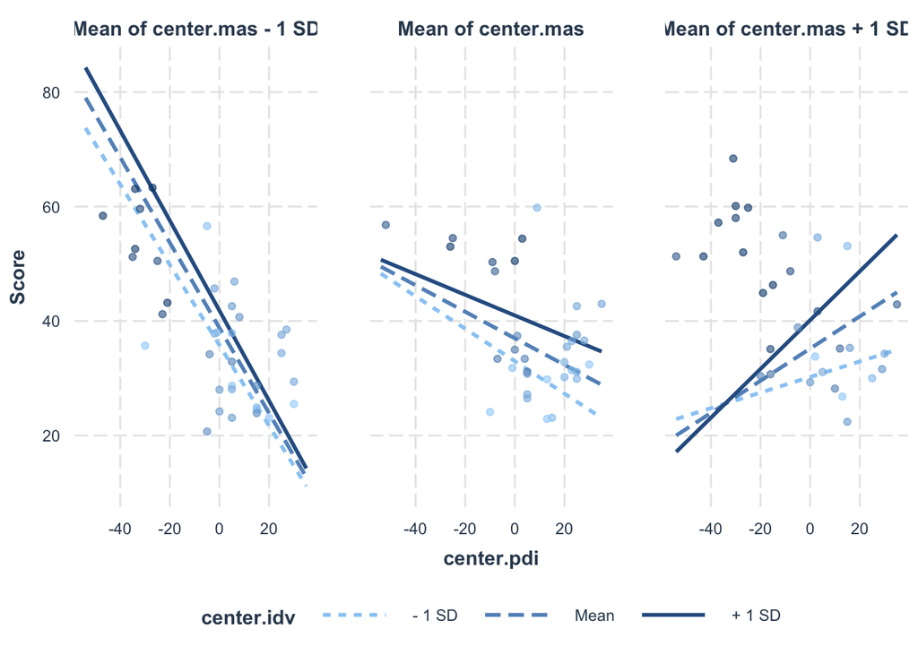

```r
interact_plot(regression_5, pred = "center.pdi", modx = "center.idv", mod2 = "center.mas", plot.points = TRUE)
```

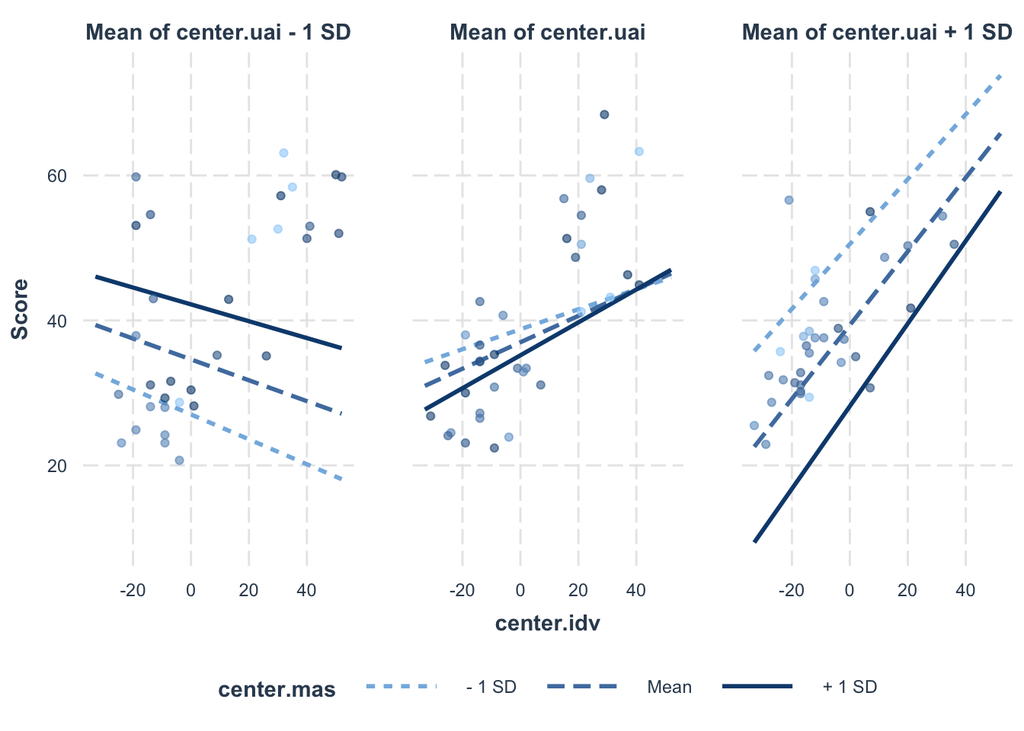

```r
interact_plot(regression_5, pred = "center.idv", modx = "center.mas", mod2 = "center.uai", plot.points = TRUE)
```

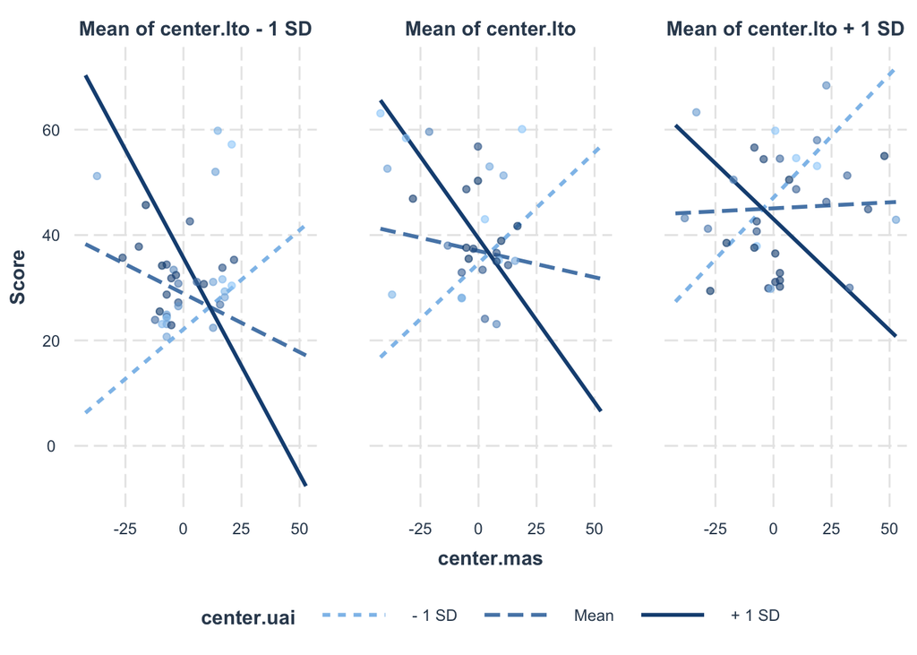

```r
interact_plot(regression_5, pred = "center.mas", modx = "center.uai", mod2 = "center.lto", plot.points = TRUE)
```

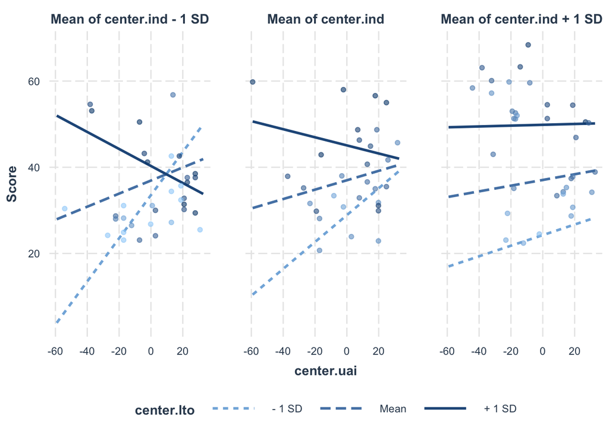

```r
interact_plot(regression_5, pred = "center.uai", modx = "center.lto", mod2 = "center.ind", plot.points = TRUE)
```

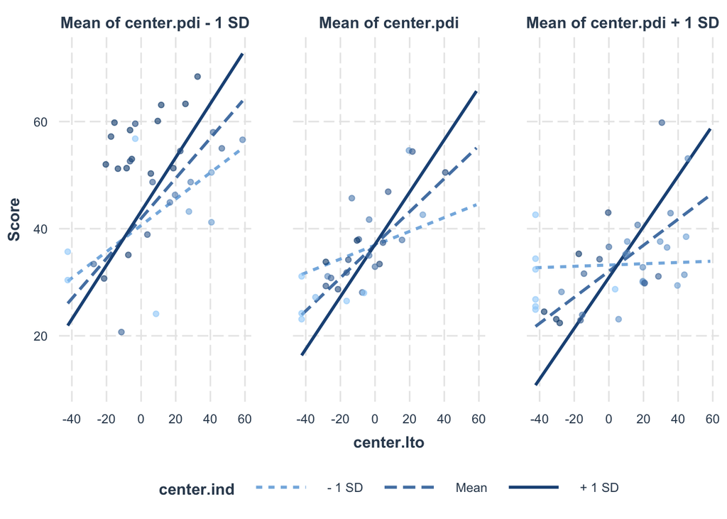

```r
interact_plot(regression_5, pred = "center.lto", modx = "center.ind", mod2 = "center.pdi", plot.points = TRUE, int.width = 0.95)
```

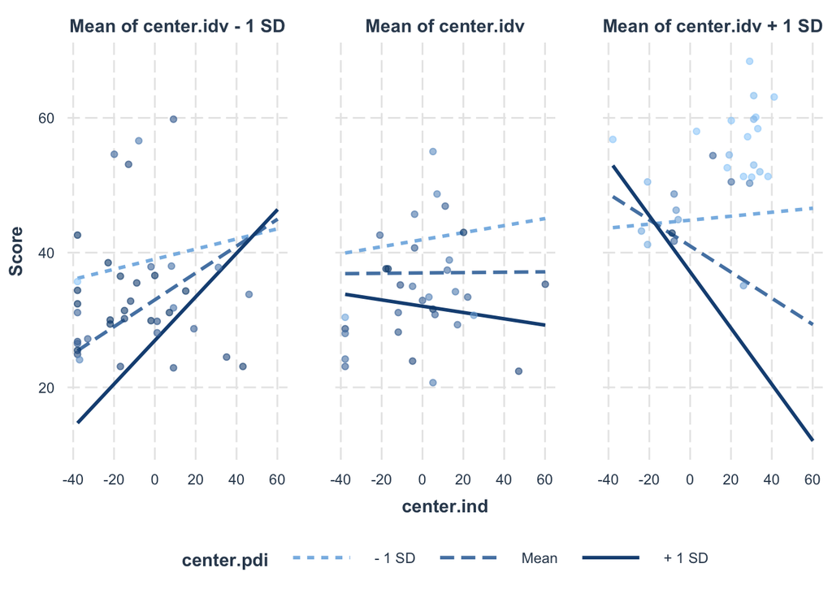

```r
interact_plot(regression_5, pred = "center.ind", modx = "center.pdi", mod2 = "center.idv", plot.points = TRUE)
```

- pred : 상호 작용과 관련된 예측 변수
- modx : 상호 작용과 관련된 중재자 변수
- mod2 : 선택 항목, 상호 작용에 관련된 두 번째 중재자 변수
- plot.point : 데이터 포인트를 산점도로 표시
- int.width : 신뢰 구간 설정
- tab_model 기반의 결과표에 비해 시각적으로 상호작용 효과를 선의 기울기와 산점도로 표현하여 더 보기 쉽다는 것을 알 수 있다. 이외에 신뢰구간 표시, 자유롭게 사용 가능한 중재 변수 등 interact.plot 함수로 나타냈을 때 얻을 수 있는 메리트가 많았다.